# Experiment 2A

## Setup

In the second part of the experiment we will go in the other direction, filtering based on PC gates and evaluating on the future. This answers the converse question, “If a set of parameters passes the gates in the PC basis, how likely is it to produce valid output?”

In the third part of the experiment, we will define likelihood functions in both the PC space and the natural space, and we will compare the results over the Hector ensemble.  
We are most interested in the correspondence of *rank ordering* and *likelihood ratio* between the two formulations.

```r
library('dplyr')
library('ggplot2')
library('ggthemes')
library('hector')
library('hectorcal')
```

```r
## We need the PC projections for the ensemble
hector_proj <- compute_pc(hector_conc_ensemble, c('historical','rcp26','rcp45','rcp60','rcp85'),
                          'tas', 2006:2100, 1861:2005, retx=TRUE)$x
## ESM projections are stored as package data: cmip_conc_pcproj
```

## Part 1: PC performance of models selected in the natural basis

### Concentration-driven runs

Start by filtering the ensemble to just the members that pass all of the gates in all the experiments.

```r
hcdata <- bind_rows(hector_conc_ensemble[1:5])      # drop the params structure and merge into a single df
cids <- chkgates(hcdata, 'tas')
length(cids)
```

```
[1] 154
```

Only 154 out of 1000 make the cut, which is a bit of a small sample size. Evidently, the parameter space defined by our priors is a lot larger than the space that actually leads to good model agreement, which is not too surprising. From here we want to grab the PC projections for the models that make the cut.

```r
projid <- as.integer(row.names(hector_proj))
hpfilter <- hector_proj[projid %in% cids, ]
```

We want to compare these to the gates established by the ESM runs, so we’ll need to pull those too.

```r
maxpc <- 15
esm_pc_stats <- group_by(cmip_conc_pcproj, PC) %>%
    summarise(min=min(value), max=max(value)) %>%
    filter(PC <= maxpc) %>% select(-PC) %>%
    as.matrix() %>% t()
colnames(esm_pc_stats) <- paste0('PC', seq(1,maxpc))
```

Now do the comparison

```r
conc_pc_cmp <- apply(hpfilter[,1:maxpc], 1, function(x) {x >= esm_pc_stats[1,] & x <= esm_pc_stats[2,]})
conc_pc_all <- apply(conc_pc_cmp, 2, all)
frac_pc_pass <- sum(conc_pc_all)/length(conc_pc_all)
conc_pc_pct <- structure(matrix(apply(conc_pc_cmp, 1, function(x) {sum(x)/length(x)}), ncol=1),
                         dimnames = list(row.names(conc_pc_cmp), 'frac'))
conc_pc_pct
```

```
          frac
PC1  0.9480519
PC2  0.8376623
PC3  0.2727273
PC4  0.6168831
PC5  0.9740260
PC6  1.0000000
PC7  1.0000000
PC8  1.0000000
PC9  1.0000000
PC10 1.0000000
PC11 1.0000000
PC12 1.0000000
PC13 1.0000000
PC14 1.0000000
PC15 1.0000000
```

```r
cat('Overall pass fraction: ', frac_pc_pass, '\n')
```

```
Overall pass fraction:  0.1363636
```

What we see here is that correspondence between filtering in the PCA basis and in the natural basis is ok, but nowhere near perfect. Only 14% of the models from our ensemble that we would have called “good” models pass all of the principal component gates. PC3 and PC4 in particular seem to be doing their own thing.

We did all this using hard boundaries, so it’s worth asking, how far outside of the PC gates are we? How big is the discrepancy here?

```r
pcviol <- apply(hpfilter[ , 1:maxpc], 1, function(x) {
    width <- esm_pc_stats[2,] - esm_pc_stats[1,]
    if_else(x < esm_pc_stats[1,], (esm_pc_stats[1,]-x)/width,
            if_else(x > esm_pc_stats[2,], (x-esm_pc_stats[2,])/width, 0))
})
row.names(pcviol) <- colnames(esm_pc_stats)
apply(pcviol, 1, function(x){mean(x[x>0])})
```

```
       PC1        PC2        PC3        PC4        PC5        PC6        PC7        PC8        PC9
0.08585770 0.11312903 1.05629967 0.10213549 0.02547156        NaN        NaN        NaN        NaN
      PC10       PC11       PC12       PC13       PC14       PC15
       NaN        NaN        NaN        NaN        NaN        NaN
```

The violations for PCs 1,2,4,and 5 are pretty small, but PC3 once again stands out as being way out of line. What I’m wondering here is, is there any discernible difference between the models that pass the PC gates and the ones that fail?

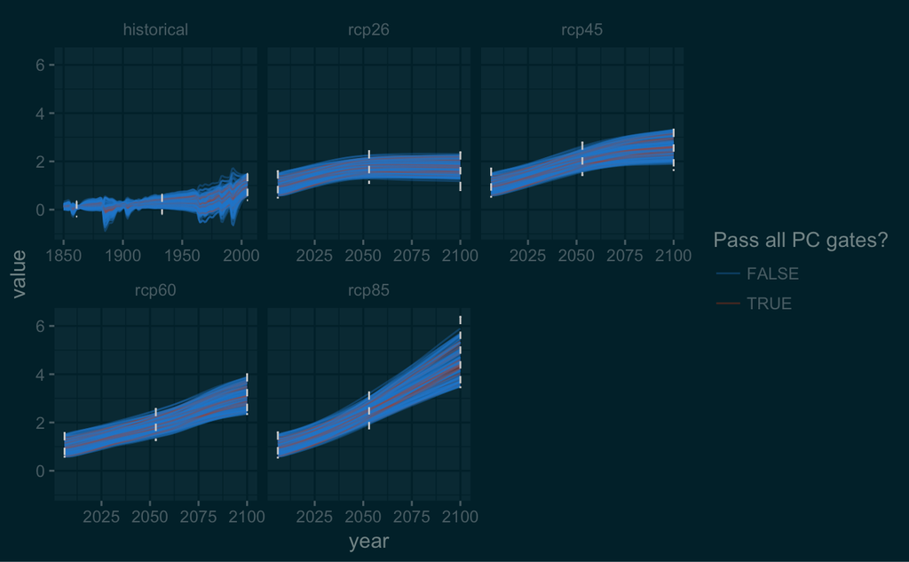

```r
pcpass <- data.frame(pass3=conc_pc_cmp[3,], allpass=apply(conc_pc_cmp, 2, all),
                     runid = as.integer(colnames(conc_pc_cmp)))
pltdata_conc <- filter(bind_rows(hector_conc_ensemble[1:5]), runid %in% cids) %>%
    left_join(pcpass, by='runid')
pltgates <- bind_rows(lapply(c('historical','rcp26','rcp45','rcp60','rcp85'), get_gates, var='tas'))
ggplot(data=pltdata_conc, aes(x=year, y=value, color=allpass, group=runid)) + geom_line(alpha=0.35) +
    geom_errorbar(data=pltgates, aes(x=year, ymin=mina, ymax=maxb), linetype=2, color='lightgrey', width=1,
                  inherit.aes = FALSE) +
    facet_wrap(~experiment, scales='free_x') + scale_color_solarized() + theme_solarized_2(light=FALSE) +
    guides(color=guide_legend(title='Pass all PC gates?'))
```

This is *very* interesting. All of the runs pass the output gates, by design. The blue runs, fail one or more of the PC gates, while the red runs pass all of the PC gates. There is no discernible difference between the red and blue runs in the future, but they are very different in the past. However, by happenstance most of the difference is in between the gate years. Because of this, filtering in the output coordinates doesn’t pick up the difference between these parameter sets. Therefore, the discrepancy between the filtering in natural coordinates and the filtering in PC coordinates is due to the fact that the PC filtering is picking up some legitimate behavior that is being missed in the natural coordinates. Many of those blue models *should* be rejected because they are misbehaving at times when we weren’t looking at them.

If we wanted to be sure to see all of those differences, we would have to put gates at more times. However, since we don’t know a priori what the critical times are to sample, we would have to lay down a *lot* of gates. That would cause us to get unreasonably narrow posterior distributions for our parameters because our Bayesian calculation would be seeing some models accrue miss after miss on all those gates, and each one would impose a penalty in the likelihood function. A model that made a brief excursion outside the envelope would be excessively penalized, and its contribution to the posterior distribution would be wrongly deweighted.

### Emissions driven runs

```r
hedata <- bind_rows(hector_emiss_ensemble[pc_emiss$meta_data$experiment])
emiss_cids <- chkgates(hedata, pc_emiss$meta_data$variable)
length(emiss_cids)
```

```
[1] 0
```

That’s right. *None* of the ensemble members passes all 12 output gates for the emission-driven runs. We could probably do some kind of thing where we select for models that pass 10 or 11 gates, but we’ll defer that for now, instead moving on to part 2.

## Part 2: Output performance of models selected in the PC basis

```r
## Tables of min, max, mean values by PC, for both sets
maxpc <- 6
esm_pc_stats <- group_by(cmip_conc_pcproj, PC) %>%
    summarise(mina=min(value), maxb=max(value)) %>%
    filter(PC <= maxpc)
##
chkpcpass <- function(proj, pc_stats) {
    hpt <- t(proj[, 1:maxpc])
    pass <- hpt >= pc_stats$mina & hpt <= pc_stats$maxb
    allpass <- apply(pass, 2, all)
    as.integer(row.names(hector_proj))[allpass]
}
pccids <- chkpcpass(hector_proj, esm_pc_stats)
length(pccids)
```

```
[1] 31
```

Not very many ensemble members pass the PC gates. Since we know that only 21 ensemble members passed both the output and PC gates, so 10 of these will fail in the output gates. As before, let’s see what the failures look like and how they differ from the ones that succeed.

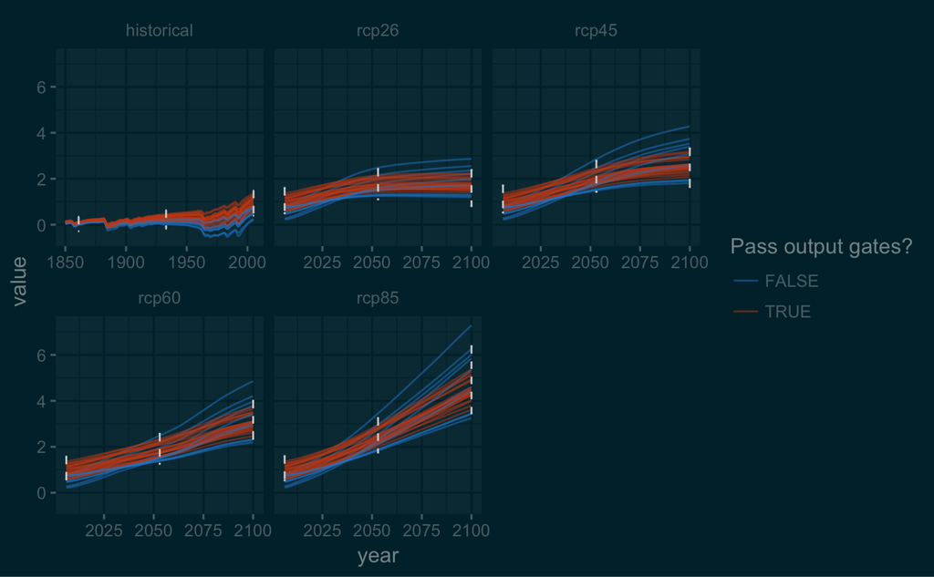

```r
hcpass <- filter(hcdata, runid %in% pccids)
cidsboth <- chkgates(hcpass, 'tas')
hcpass <- mutate(hcpass, outgates = runid %in% cidsboth)
ggplot(data=hcpass, aes(x=year, y=value, color=outgates, group=runid)) + geom_line(alpha=0.5) +
    geom_errorbar(data=pltgates, aes(x=year, ymin=mina, ymax=maxb), linetype=2, color='lightgrey', width=1,
                  inherit.aes = FALSE) +
    facet_wrap(~experiment, scales='free_x') + scale_color_solarized() + theme_solarized_2(light=FALSE) +
    guides(color=guide_legend(title='Pass output gates?'))
```

As expected, a few of the selected ensemble members don’t pass the gates, but the violations are relatively small. These models would be slightly disfavored, but their log-likelihood scores probably wouldn’t be terrible. I’m reasonably pleased with the performance of the PC-selected runs on the output gates.

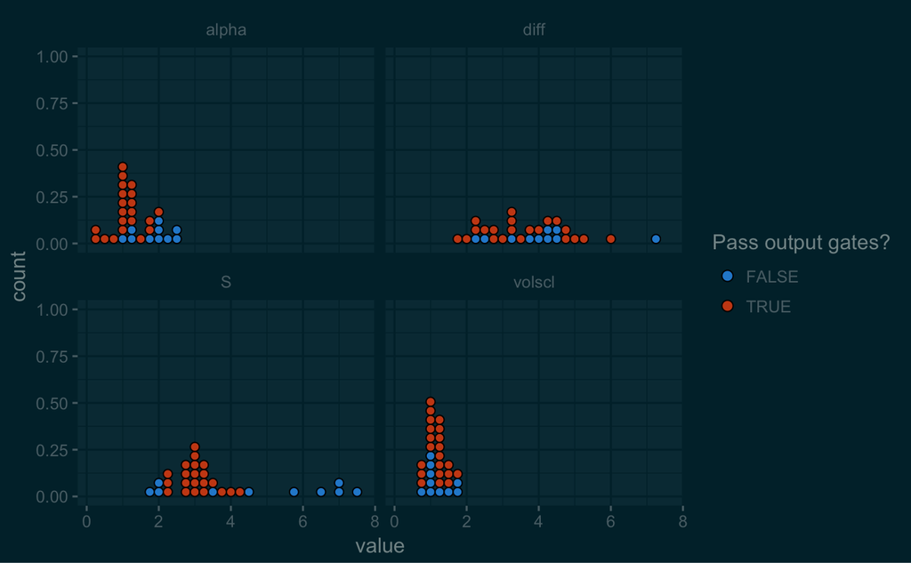

```r
pltparms <- filter(hector_conc_ensemble$params, runid %in% pccids) %>%
    mutate(outgates=runid %in% cidsboth) %>%
    tidyr::gather(key='parameter', value='value', -runid, -outgates)
ggplot(data=pltparms, aes(x=value, fill=outgates)) +
    geom_dotplot(binwidth=0.25, stackgroups=TRUE, binpositions='all', method='histodot') +
    facet_wrap(~parameter) +
    guides(fill=guide_legend(title='Pass output gates?')) +
    theme_solarized_2(light=FALSE) + scale_fill_solarized()
```

For the most part, it looks as if output gate violations are associated with exceptionally large or small values of climate sensitivity ($S$). Only one violation occurred with $S$ in the interior core of the distribution; that was run #474, which had $\alpha = 2.1$. Large $\alpha$ values also seemed to be associated with violations, but there were a few values in the interior core of the distribution that also showed violations. Diffusion and volcanic scaling didn’t show any obvious pattern.

This suggests we might see somewhat larger values for $S$ and $\alpha$ than we might have seen, had we filtered on the output gates. Let’s compare this with the patterns shown by the concentration-selected runs and see if this is true.

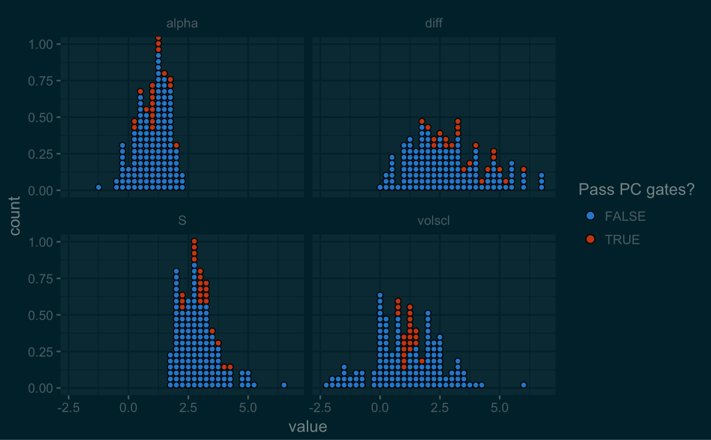

```r
pltdata2 <- filter(hector_conc_ensemble$params, runid %in% cids) %>%
    left_join(pcpass, by='runid') %>%
    tidyr::gather(key='parameter', value='value', -runid, -pass3, -allpass)
ggplot(data=pltdata2, aes(x=value, fill=allpass)) +
    geom_dotplot(binwidth=0.25, stackgroups=TRUE, binpositions='all', method='histodot') +
    facet_wrap(~parameter) +
    guides(fill=guide_legend(title='Pass PC gates?')) +
    theme_solarized_2(light=FALSE) + scale_fill_solarized()
```

The largest values of $S$ in the PC-selected runs are a little larger, but not as much so as you might think. There are a lot of output-selected runs with $S$ values around 5, and one a bit over 6. By comparison, the PC-selected values top out between 7 and 8. Meanwhile, the top end of the $\alpha$ distribution seems the same between the two runs methods, and in the output-selected version the bottom end of $\alpha$ seems unrealistically low.

## Part 3: Correspondence between likelihood functions defined in output and PC spaces

At the beginning of this exercise we said that we expected to see good correspondence between likelihood functions defined in the output and PC spaces. Now that we know that looking in the output space misses some important features, it’s not clear that that correspondence will be all that great, but we will still want to know how they compare. Join us, won’t you?

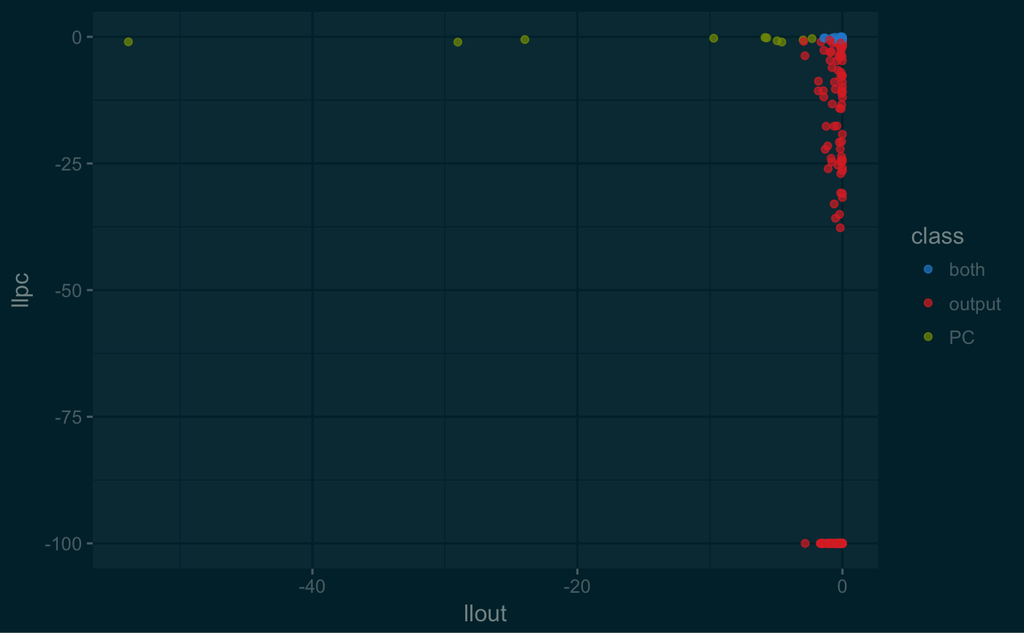

```r
runids <- as.integer(row.names(hector_proj))
likelihood_pc <- function(runid) {
    maxpc <- nrow(esm_pc_stats)
    i <- which(runids == runid)
    pcvals <- hector_proj[i,1:maxpc]
    mina <- esm_pc_stats$mina[1:maxpc]
    maxb <- esm_pc_stats$maxb[1:maxpc]
    sig <- 0.1*(maxb-mina)
    sum(log(mesa(pcvals, mina, maxb, sig)))
}
conc_lldata <- filter(hcdata,
                      variable %in% unique(pltgates$variable),
                      experiment %in% unique(pltgates$experiment),
                      year %in% unique(pltgates$year)) %>%
    select(runid, year, variable, experiment, value) %>%
    arrange(runid, experiment, variable, year)
likelihood_out <- function(rid) {
    outdata <- filter(conc_lldata, runid==rid)
    mina <- pltgates$mina
    maxb <- pltgates$maxb
    sig <- 0.1*(maxb-mina)
    sum(log(mesa(outdata$value, mina, maxb, sig)))
}
llpc <- sapply(runids, likelihood_pc)
llpc <- llpc - max(llpc)
llpc[is.infinite(llpc)] <- -100       # We get a fair few -Inf values.  Set them to an arbitrary large negative value.
llout <- sapply(runids, likelihood_out)
llout <- llout - max(llout)
llout[is.infinite(llout)] <- -350
ispc <- runids %in% pccids
isout <- runids %in% cids
class <- if_else(ispc,
                 if_else(isout, 'both', 'PC'),
                 if_else(isout, 'output', 'neither'))
llvals_conc <- data.frame(llpc=llpc, llout=llout, class=class) %>% filter(class != 'neither')
ggplot(data=llvals_conc, mapping=aes(x=llout, y=llpc, color=class)) + geom_point(alpha=0.7) +
    theme_solarized_2(light=FALSE) + scale_color_solarized()
```

I’ve filtered the “neither” class of parameters that fail both sets of gates because both likelihood functions are saying those parameter combinations are terrible, and we don’t really care about the nuances of exactly how terrible they are. In the data that remains, we see that there is a large group of runs that the output likelihood says are pretty good, but to which the PC likelihood assigns varying degrees of badness. We think we know why that is, so we’ll filter those and replot.

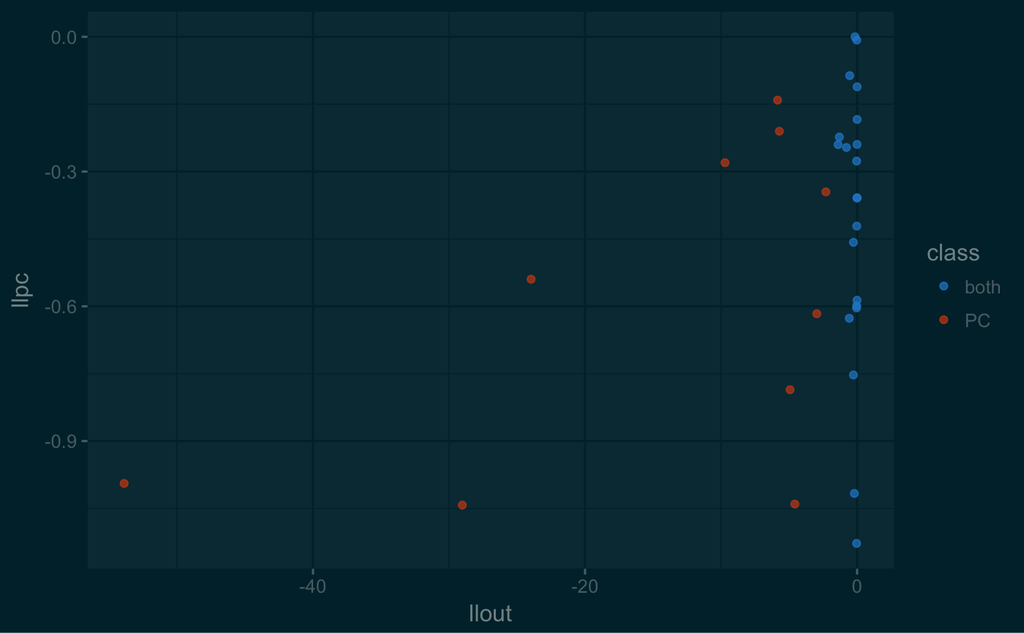

```r
llvals_conc2 <- filter(llvals_conc, class != 'output')
ggplot(data=llvals_conc2, mapping=aes(x=llout, y=llpc, color=class)) + geom_point(alpha=0.7) +
    theme_solarized_2(light=FALSE) + scale_color_solarized()
```

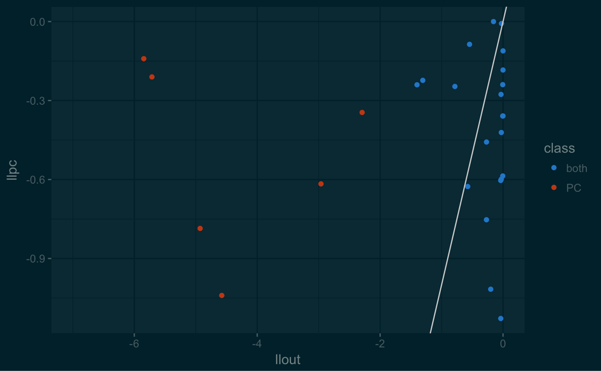

```r
ggplot(data=llvals_conc2, mapping=aes(x=llout, y=llpc, color=class)) + geom_point() +
    theme_solarized_2(light=FALSE) + scale_color_solarized() + xlim(c(-7,0)) +
    geom_abline(slope=1, intercept=0, color='lightgrey')
```

Then again, if the two methods agreed perfectly, there wouldn’t be any reason to go to the trouble of computing the principal components in the first place. What we’re trying to do here is argue that the the PC method *generally* comports with our intuition about what constitutes a good model, which I think it does. We will, however, probably have to give some careful thought to how we explain this choice in the paper.